# Homework 3

Kaylyn Zipp

3/1/2021

1. Fit a logistic regression model that assumes the probability of success is an additive function of variables x1 and x2.

Equation: y = b0 +b1* x1 + b2 * x2b

2. Interpret the effect of variable x1 on the log odds of success. Verify your interpretation in R.

```r
b<-coef(fit)
b[2]
```

```
##        x1
## -0.167976
```

```r
#Justified
#Set x2b to zero and do a 1 unit change
p_1_x1 <- plogis(b[1] + b[2] * 1 + b[3] * 0)
p_1_x1
```

```
## (Intercept)
##   0.6051269
```

```r
p_2_x1 <- plogis(b[1] + b[2] * 2 + b[3] * 0)
p_2_x1
```

```
## (Intercept)
##   0.5643653
```

```r
logs_odd_ratio_x1<-log((p_2_x1/ (1 - p_2_x1)) / (p_1_x1 / (1 - p_1_x1)))
print(logs_odd_ratio_x1)
```

```
## (Intercept)
##   -0.167976
```

The slope coefficient represents the change in log odds associated with a 1-unit change in the predictor variable so with a 1 unit change in x1 the logs odds decreases by -0.167976.

3. Interpret the effect of variable x2 on the log odds of success. Verify your interpretation in R.

```r
b<-coef(fit)
b[3]
```

```
##        x2b
## -0.9679244
```

```r
p_0_x2b <- plogis(b[1] + b[2] * 1 + b[3] * 0)
p_0_x2b
```

```
## (Intercept)
##   0.6051269
```

```r
p_1_x2b <- plogis(b[1] + b[2] * 1 + b[3] * 1)
p_1_x2b
```

```
## (Intercept)
##   0.3679432
```

```r
logs_odd_ratio_x2<-log((p_1_x2b / (1 - p_1_x2b)) / (p_0_x2b / (1 - p_0_x2b)))
print(logs_odd_ratio_x2)
```

```
## (Intercept)
##  -0.9679244
```

4. Duplicate the Wald Test and p-values for variables x1 and x2 performed by the glm() function. Do you reject or fail to reject your null hypothesis?

X1 Wald Test

```r
ts<-b[2] / summary(fit)[['coefficients']]['x1', 'Std. Error']
X1WaldTest<-2 * pnorm(-1 * abs(ts), mean = 0, sd = 1)
print(X1WaldTest)
```

```
##        x1
## 0.6451594
```

Fail to reject the null hypothesis

X2b Wald Test

```r
ts<-b[3] / summary(fit)[['coefficients']]['x2b', 'Std. Error']
X2bWaldTest<-2 * pnorm(-1 * abs(ts), mean = 0, sd = 1)
print(X2bWaldTest)
```

```
##        x2b
## 0.01926485
```

Reject the null hypothesis

5. Predict and plot the mean probability of success over the range of values of x1.

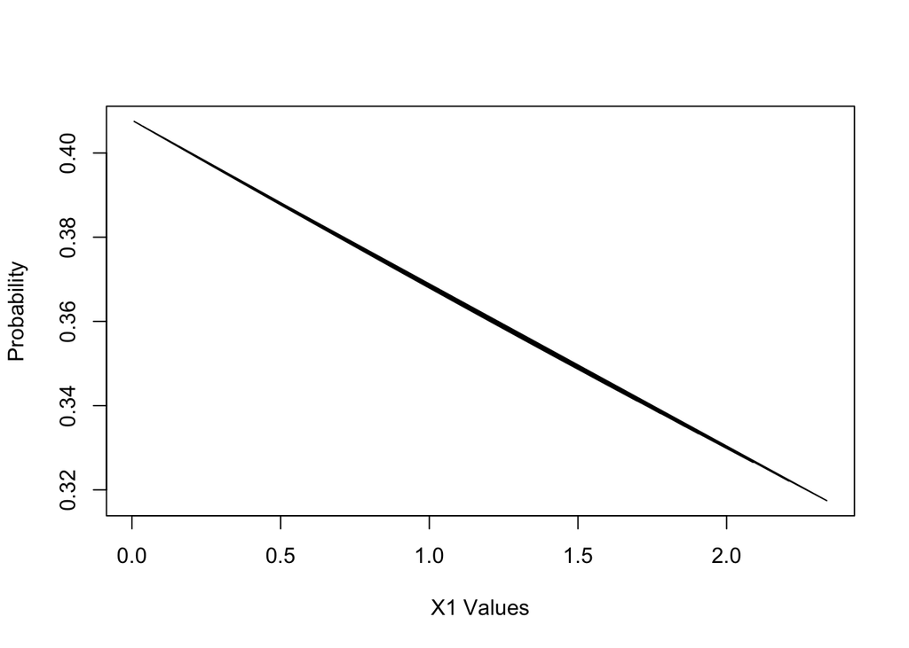

```r
#We will set 2xb to 1
X1<-Hw3$x1

ProbabilityPredict <- plogis(b[1] + b[2] * X1 + b[3] * 1)

plot(y = ProbabilityPredict, x = X1, type = 'l',xlab = 'X1 Values', ylab = 'Probability')
```